# Lab 3 - 19001395 - V

# Ejercicio 3

## Modelo 1

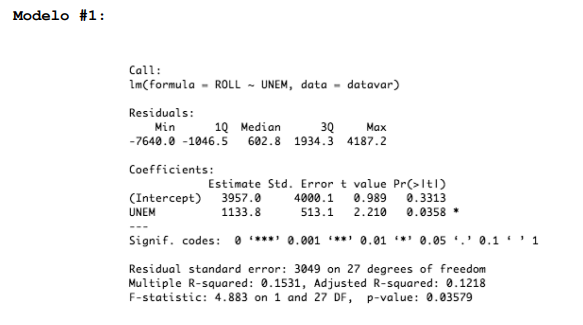

Modelo1

## Modelo 2

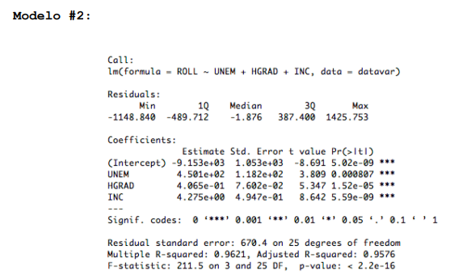

Podemos apreciar que este modelo es el que tiene el mejor rendimiento para predecir ROLL al tomar en cuenta todas las variables podemos ver que existe un significancia entre todas las variables, lo cuál nos indica que estas tienen una relación importante para poder predecir la variable ROLL, tiene un $R^2$ alto lo cual dice que tiene buen ajuste con los datos y un F statistic alto que indica que tendrá un buen desempeño general, habría que poner a prueba el desempeño del modelo contra los datos de validación para asegurarnos que no hay overfitting por tener un $R^2$ tan alto.

## Modelo 3

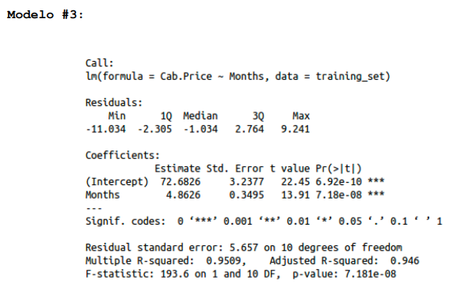

El modelo 3 tiene un buen desempeño al tener un $R^2$ alto lo cual indica que hay buen ajuste de los valores, los valores tienen una significancia alta lo cual indica que hay una buena relación entre las variables para poder predecir el precio del taxi, por último tenemos un F statistic alto que indica un buen rendimiento general.